# Syllabus

## Overview and Goals

The Biden administration’s [Executive Order 13895](https://www.whitehouse.gov/briefing-room/presidential-actions/2021/01/20/executive-order-advancing-racial-equity-and-support-for-underserved-communities-through-the-federal-government/) calls on the Federal Government to advance equity in order “to provide everyone with the opportunity to reach their full potential.” One admission embedded in this charge is that the policies that order our common life have not historically centered equity.

What would it mean to prioritize equity in policy? What are the possibilities for more universal inclusion, belonging, and flourishing? How might we evaluate the way current policies or proposals support or hide inequitable processes, outcomes, or treatment? And how can equity be operationalized across stages of the policy process – from problem identification and formulation, to policy intervention and analysis, and policy design and implementation? These are the questions that will shape our work.

Over the course of the semester, we will develop a roadmap for equitable policy choice and evaluation. There is no ready guidebook for how to understand what an equitable policy process or policy choices or policy designs look like. We will work together over the course of the semester to imagine where an equity lens could be usefully incorporated in policy.

A few of our learning goals:

- Be able to recognize and explain different concepts of equity in the policy domain;
- Practice applying various tools and measures of equity to governmental action;
- Evaluate policy alternatives with respect to equity and additional principles;
- Develop deeper understanding of a selected policy area.

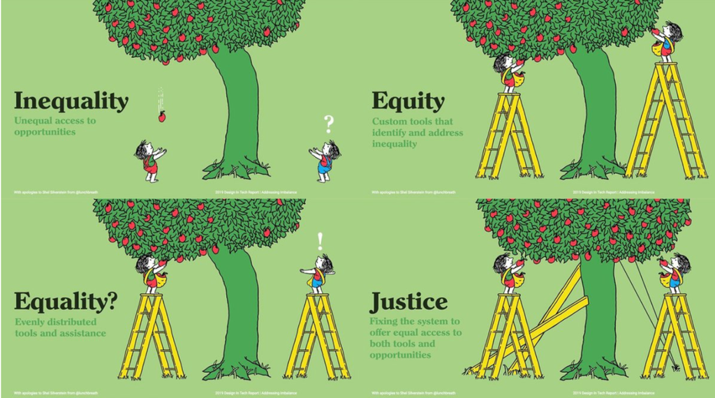

## Evaluation of Our Work

### Contributions to Material/Class (45%)

This set of assignments is directed at supporting both individual and collective understanding of the reading in a way that prepares everyone to contribute to the team projects.

#### Reading annotations (27%)

To facilitate understanding and discussion we’ll all contribute to collaborative annotation and commenting on the reading using Perusall by noon Tuesday. I will review these ahead of class to help organize our discussion.

We have reading assigned on eleven out of fourteen weeks (excluding week 1). Contributing annotations to readings for at least nine weeks is necessary for full credit. Make at least four full contributions for a given week’s reading.

A full contribution will go beyond agreeing with a point or asking a question. It will engage a point, connect it to other ideas we might learn from, amend it to suggest a more limited or wider scope, note conditions under which it is more or less relevant, ponder how it might inform your project or other work of which you are aware, ask a question and provide an initial answer. If others have already commented on a passage and you want to address and elaborate on the initial comment (beyond basic agreement), you should. Think about the kinds of things you might raise in a discussion and bring them up in the annotations.

#### In-Class Practice (14%)

In about half of the weeks, we’ll spend some part of class putting ideas into practice or providing feedback to one another on the team-based projects.

#### Course Material Recommendation (4%)

By the end of the semester, suggest one new resource for this course – it might be an academic article, a white paper or report from a policy organization, a podcast or multimedia piece, a science fiction or other literary selection, or something else. Submit this suggestion to me along with a paragraph outlining why you find it relevant or useful.

### Project Work (55%)

We will test and expand our understanding through a series of team-based projects. Grades will depend on your learning and contribution to this collective effort, which will be assessed by a combination of individual work and team work. All of the final submissions from our project work will be shared on the course website!

#### The Meaning of Equity (15%)

In the first project, we’ll explore what “equity” means to the federal government by coding the content of the Equity Action Plans submitted by federal agencies. Based on our reading and collective understanding, we’ll create an initial coding scheme. Individuals will use the scheme to code the Equity Action Plan of two agencies and then teams will work together to compare document coding and understanding for a subset of agencies. Teams will generate a short write up (~3 single-spaced pages) presenting the results for their agencies and providing a narrative interpretation of the definitions of equity in these contexts and how they might connect to the ways the relevant agencies define and represent problems and construct the agencies’ clients and stakeholders.

- Tuesday, 8/30: Coding scheme developed in class, teams defined
- (5%) Tuesday, 9/6: Individuals submit initial completed coding for two documents (these will overlap within a team so that each document is reviewed and coded by two members)
- (10%) Tuesday, 9/20 (or Friday, 9/23): Teams submit completed coding for their subset of documents and narrative write up (~3 single-spaced pages)

#### Policy Assessment Brief (17.5%)

In the policy assessment brief, you’ll (a) identify the problem, people, and place of your policy focus, including a description of the problem and the policy status quo in your selected context (what are the current policies, current outcomes, ongoing challenges, and possibly additional problems created by the current policy). Following a description of the problem and context, you’ll (b) provide an equity assessment of the current state; this should include a description of how the policy or challenges vary across sub-populations and an evaluation of the problem representation in current policy (think Bacchi’s work) and how this might contribute to or hinder equity.

- (5%) Friday, 9/30: Individuals submit individual pre-brief sketch of the policy landscape for your team’s chosen policy focus, including a brief description of the problem and policy status quo in your selected context (~ 1-2 single-spaced pages). You’ll share your individual pre-brief sketches with one another to learn from one another and negotiate a focus.
- Tuesday, 10/11: Team peer feedback
- Tuesday, 10/18: Presentation
- (12.5%) Friday, 10/21: Teams submit completed brief (~ 4-6 single-spaced pages)

#### Policy Recommendation Brief (17.5%)

In the policy recommendation brief, you’ll briefly restate the problem you’re addressing and how the target populations are impacted. Then you’ll (a) describe two policy changes or alternatives to improve conditions for your focal population. For each change or intervention, explain how it improves the status quo as detailed in the policy assessment brief. Who is most benefited by the proposed alternative? Does it address the cause of the problem or seek to mitigate challenges? What’s the chain that leads from policy change to improvement for people? And how does it alter the equity assessment for the policy area you’re working on?

The brief should end with a recommendation for one of the alternatives (or status quo). (b) For the chosen policy change, explain why you selected it and provide implementation suggestions or guidelines. Who should be designing and executing the policy to ensure a positive experience for focal populations? How might administrative burdens be reduced?

#### Policy Communication (5%)

Present an abbreviated version of the key information in your policy assessment and/or recommendation briefs in a creative way, something aimed at informing a broader public or impacted populations. This could take any form – a short (less than 5 minutes) podcast, a cartoon explainer, a brief video, a tweet thread with gifs, an infographic, something else (e.g., material appropriate for other social media forms). Any format you think could be useful for public communication and education! You may choose to emphasize problems or solutions; it could be advocating for something or purely informational. The key is to make it legible to a wider audience to promote public engagement in the policy arena.

- Tuesday, 12/6: Draft presentation
- Tuesday, 12/13: Teams submit final piece

#### Centering People in Places: Policy Briefs

One starting point for us will be the assumption that equitable policy centers people, that policies are oriented toward solving the problems people are facing or in creating conditions for people to thrive. Thus, our applied work will begin by centering people. The distinction requires a mental shift away from abstractions – e.g., homelessness – to concrete experiences of people – e.g., the obstacles faced by those who live without stable housing. The selected population need not be the only group considered in the policy briefs – ideally, policy alternatives will improve conditions for many – but will serve as an anchoring point.

Once a population is centered, you’ll select a state or locality to focus on. Given the current trend toward more state power and state-centered policy, the policy focus for the briefs will emphasize problems, people, and policies on the state or local level. The ultimate policy focus might be generalizable across states, cities, and counties, but to keep things concrete, your briefs will use a selected place to research and describe.

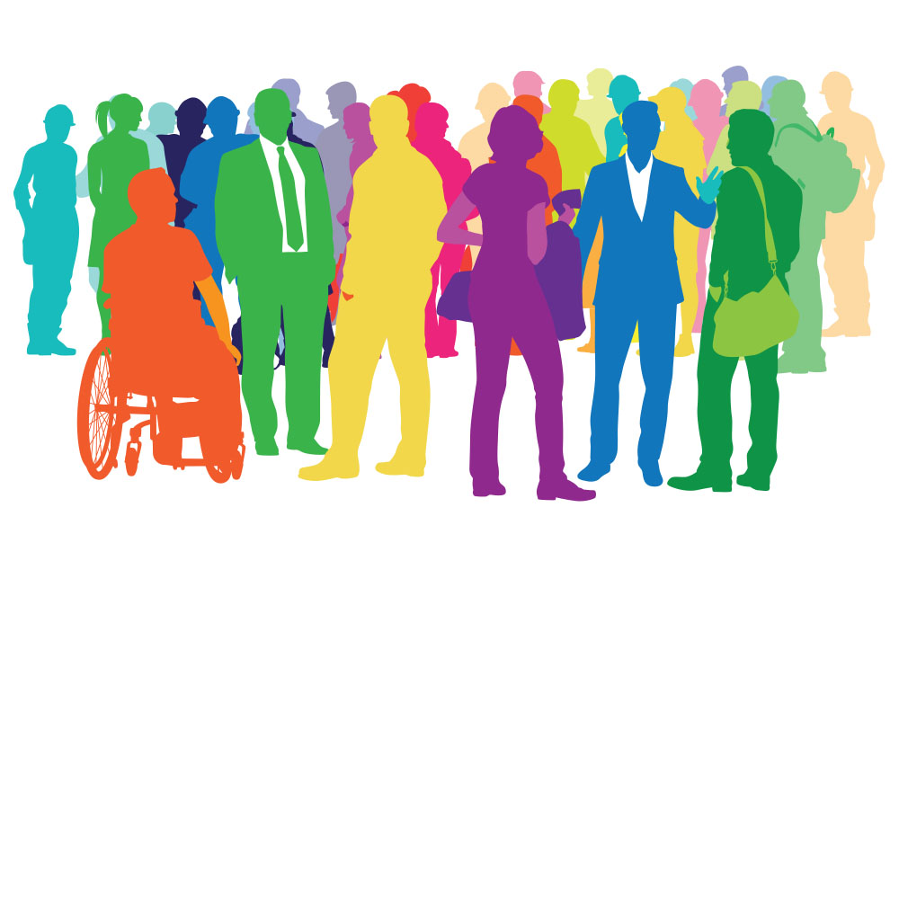